# housingPrice

This is a program which predicts the price of houses through a regression algorithm, random forest

First we install the necessary libraries in order to perform the task pandas is used for reading the csv file in the program sklearn is used to multiple times to import the algorithm, a function to test the accuracy of the program and the function that splits the data into test and training data

imports the dataset for the housing prices

```python
import pandas as pd
import numpy as np
import seaborn as sns
import matplotlib.pyplot as plt
from sklearn.linear_model import LinearRegression
from sklearn.ensemble import RandomForestRegressor
from sklearn.metrics import mean_absolute_percentage_error
from sklearn.model_selection import train_test_split
```

```python
housing_data = pd.read_csv("housingData.csv")
```

Creates a list, features, which consists of the columns that are used to train the model

```python
features = ['bedrooms', 'bathrooms', 'sqft_living', 'sqft_lot', 'view',
            'waterfront', 'floors', 'condition', 'grade', 'lat','long',
            'yr_built', 'sqft_basement', 'sqft_living15', 'zipcode', 'yr_renovated',
            'sqft_lot15']
```

**Data Preperation**

```python
housing_data
```

|  | price | bedrooms | bathrooms | sqft_living | sqft_lot | floors | waterfront | view | condition | grade | sqft_above | sqft_basement | yr_built | yr_renovated | zipcode | lat | long | sqft_living15 | sqft_lot15 |
| --- | --- | --- | --- | --- | --- | --- | --- | --- | --- | --- | --- | --- | --- | --- | --- | --- | --- | --- | --- |
| 0 | 221900.0 | 3 | 1.00 | 1180 | 5650 | 1.0 | 0 | 0 | 3 | 7 | 1180 | 0 | 1955 | 0 | 98178 | 47.5112 | -122.257 | 1340 | 5650 |
| 1 | 538000.0 | 3 | 2.25 | 2570 | 7242 | 2.0 | 0 | 0 | 3 | 7 | 2170 | 400 | 1951 | 1991 | 98125 | 47.7210 | -122.319 | 1690 | 7639 |
| 2 | 180000.0 | 2 | 1.00 | 770 | 10000 | 1.0 | 0 | 0 | 3 | 6 | 770 | 0 | 1933 | 0 | 98028 | 47.7379 | -122.233 | 2720 | 8062 |
| 3 | 604000.0 | 4 | 3.00 | 1960 | 5000 | 1.0 | 0 | 0 | 5 | 7 | 1050 | 910 | 1965 | 0 | 98136 | 47.5208 | -122.393 | 1360 | 5000 |
| 4 | 510000.0 | 3 | 2.00 | 1680 | 8080 | 1.0 | 0 | 0 | 3 | 8 | 1680 | 0 | 1987 | 0 | 98074 | 47.6168 | -122.045 | 1800 | 7503 |
| ... | ... | ... | ... | ... | ... | ... | ... | ... | ... | ... | ... | ... | ... | ... | ... | ... | ... | ... | ... |
| 21608 | 360000.0 | 3 | 2.50 | 1530 | 1131 | 3.0 | 0 | 0 | 3 | 8 | 1530 | 0 | 2009 | 0 | 98103 | 47.6993 | -122.346 | 1530 | 1509 |
| 21609 | 400000.0 | 4 | 2.50 | 2310 | 5813 | 2.0 | 0 | 0 | 3 | 8 | 2310 | 0 | 2014 | 0 | 98146 | 47.5107 | -122.362 | 1830 | 7200 |
| 21610 | 402101.0 | 2 | 0.75 | 1020 | 1350 | 2.0 | 0 | 0 | 3 | 7 | 1020 | 0 | 2009 | 0 | 98144 | 47.5944 | -122.299 | 1020 | 2007 |
| 21611 | 400000.0 | 3 | 2.50 | 1600 | 2388 | 2.0 | 0 | 0 | 3 | 8 | 1600 | 0 | 2004 | 0 | 98027 | 47.5345 | -122.069 | 1410 | 1287 |
| 21612 | 325000.0 | 2 | 0.75 | 1020 | 1076 | 2.0 | 0 | 0 | 3 | 7 | 1020 | 0 | 2008 | 0 | 98144 | 47.5941 | -122.299 | 1020 | 1357 |

21613 rows × 19 columns

Checking if any columns has null values is important because it can skew the data and lowers the models accuracy.

```python
pd.isnull(housing_data).sum()
```

```
price            0
bedrooms         0
bathrooms        0
sqft_living      0
sqft_lot         0
floors           0
waterfront       0
view             0
condition        0
grade            0
sqft_above       0
sqft_basement    0
yr_built         0
yr_renovated     0
zipcode          0
lat              0
long             0
sqft_living15    0
sqft_lot15       0
dtype: int64
```

From the function about we see there are no null values.

Next we checked if the price column was skewed. A random forest utilizes a decision tree which makes the removing of outliers unimportant to the model.

```python
(housing_data['price']).skew()
```

```
4.021715573048684
```

We turned the housing column in order to create a histogram with normal distribution. This will allow a better representation of the data and remove the skewness that is in the data set currently.

```python
data_log = np.log(housing_data['price'])
```

creates the histogram.

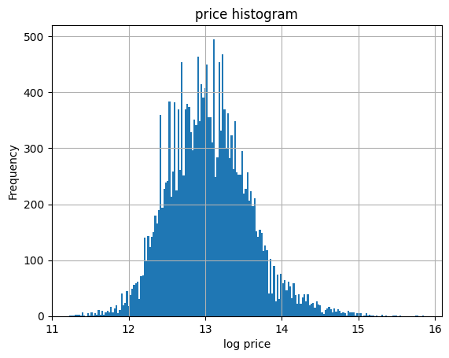

```python
data_log.hist(bins=200)
plt.title('price histogram')
plt.xlabel('log price')
plt.ylabel('Frequency')
```

This histogram is used to show the tendency of the data. The log function creates a better visual for the histogram and does a good job representing the data.

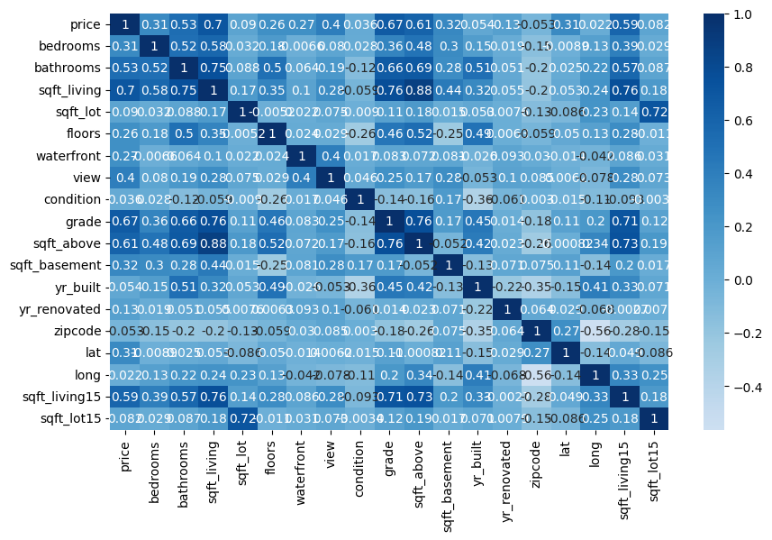

```python
fig, ax = plt.subplots(figsize=(10,6))
sns.heatmap(housing_data.corr(), center=0, cmap='Blues', annot = True)
```

Create a scatter plot to show correlation between price and the square feet of the houses.

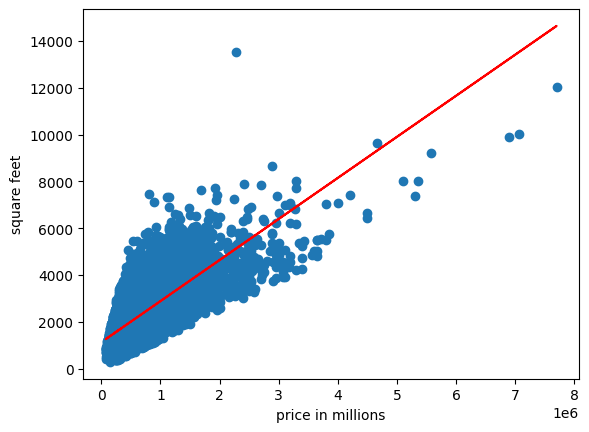

```python
x = housing_data['price'].values.reshape(-1, 1)
y = housing_data['sqft_living'].values.reshape(-1, 1)

model = LinearRegression()
model.fit(x, y)

slope = model.coef_[0][0]
intercept = model.intercept_[0]

y_fit = slope * x + intercept

plt.scatter(x, y, label='Data Points')
plt.plot(x, y_fit, color='red')
plt.xlabel('price in millions')
plt.ylabel('square feet')
plt.show()
```

**Creating the Random Forest model**

Assigns the features of the model to the X constraint

```python
X = housing_data[features]
```

The models goal is to predict the prices of houses in a certain city so the target is price so it is assigned to y. The log form of the price is used for better distribution and model accuracy.

```python
y = data_log
```

Utilizes test train split in order to train the model and then randomly creates new data in order to test the model.

```python
X_train, X_test, y_train, y_test = train_test_split(X, y, random_state=0)
```

Creates a random forest which is a regression algorithm that creates multiple decision trees.

```python
random_forest = RandomForestRegressor(random_state=1)
```

fits the training data the random forest and then gives the model new data for it to predict the values.

```python
random_forest.fit(X_train, y_train)
housing_prediction = random_forest.predict(X_test)
```

Measures the distance between the models price of a house and the actual price.

```python
print(mean_absolute_percentage_error(y_test, housing_prediction))
print(housing_prediction)
```

```
0.009467111655195013
[12.63779293 14.34364208 13.12060842 ... 13.45983608 12.8533481
 13.32703911]
```

```python
print(np.exp(housing_prediction))
```

```
[ 307980.86531761 1695760.85400799  499123.2883914  ...  700700.6784948
  382065.78908534  613563.53946164]
```